# Preliminary Data Review

Graham Tierney

6/24/2020

## Summary Statistics

We focus on the period from Feburary 1st to June 20th. The states with female governors as of these dates are: Alabama (R), Iowa (R), Kansas (D), Maine (D), Michigan (D), New Mexico (D), Oregon (D), Rhode Island (D), and South Dakota (R). We also include the mayor of DC (D), and the governors of Guam (D) and Puerto Rico (NPP). In total, we have 12 female officials.

|  | F (N=12) | M (N=41) | Overall (N=53) |
| --- | --- | --- | --- |
| N Non-Covid Tweets |  |  |  |
| Mean (SD) | 2270 (1030) | 2430 (745) | 2400 (809) |
| Median [Min, Max] | 2820 [345, 3160] | 2760 [471, 3130] | 2800 [345, 3160] |
| N Covid Tweets |  |  |  |
| Mean (SD) | 255 (215) | 391 (341) | 360 (320) |
| Median [Min, Max] | 186 [0, 760] | 272 [63.0, 1600] | 270 [0, 1600] |
| N Twitter Followers |  |  |  |
| Mean (SD) | 84900 (92500) | 213000 (443000) | 184000 (394000) |
| Median [Min, Max] | 46300 [1520, 309000] | 66600 [5050, 2310000] | 63200 [1520, 2310000] |
| Republican |  |  |  |
| Yes | 3 (25.0%) | 23 (56.1%) | 26 (49.1%) |
| No | 9 (75.0%) | 18 (43.9%) | 27 (50.9%) |
| Mean RTs of Covid Tweets |  |  |  |
| Mean (SD) | 141 (146) | 281 (577) | 251 (519) |
| Median [Min, Max] | 81.1 [17.3, 423] | 84.2 [7.28, 3010] | 82.7 [7.28, 3010] |
| Missing | 1 (8.3%) | 0 (0%) | 1 (1.9%) |
| Mean RTs of Non-Covid Tweets |  |  |  |
| Mean (SD) | 60.5 (57.8) | 152 (301) | 131 (268) |
| Median [Min, Max] | 38.4 [17.1, 226] | 56.4 [9.15, 1500] | 54.1 [9.15, 1500] |

## Temporal Trends

Next, we show some plots of the number of tweets and engagement with tweets over time. We observe almost no covid-related tweets in February, with a sharp rise in March and gradual decline.

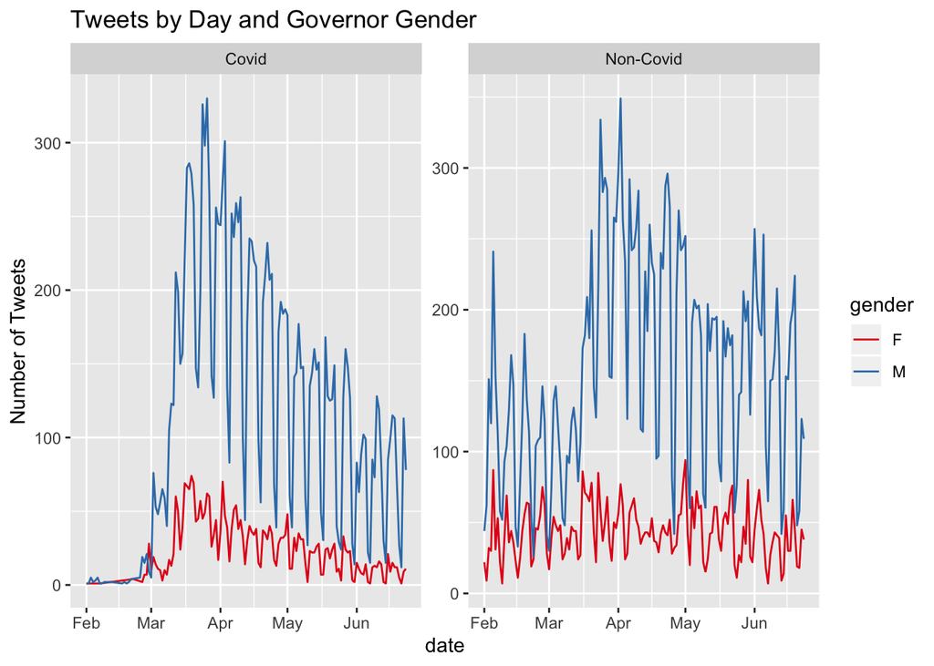

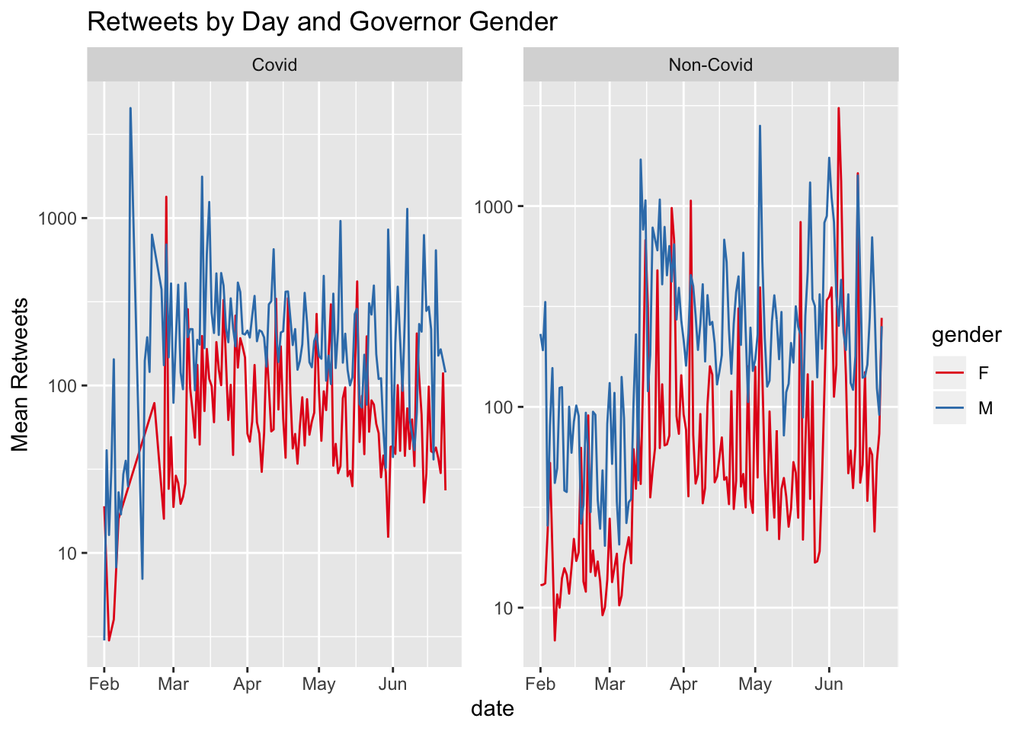

### Analysis

For analysis, we run regressions at the tweet-level. The outcome is either number of retweets or favorites. We take the log of the outcome because of the substantial right-skew. In even columns, we include indicator variables for each governor. This prevents us from looking directly at gender or other state-level characteristics because it is co-linear with the indicators. A large part of the individual-level effect, however, is encoded in the follower counts of each governor, measured at the end of the period. In odd columns, we drop the indicators and include follwer count (standardized to mean zero, variance one) to look at gender specifically.

followers_count 0.804*** 0.960***  
(0.006) (0.011)

covidTweetTRUE:genderM -0.104*** 0.033 -0.263*** 0.135***  
(0.033) (0.030) (0.060) (0.051)

Constant 2.676*** 1.925*** 2.935*** 3.540***  
(0.163) (0.155) (0.298) (0.265)

Somewhat puzzling are oposite effects for retweets and favorites. Men are favorited more and retweeted less.